# Causality

Fall 2019

## Course business

## Review: A typical week

**Monday**: skim/read chapter; start DataCamp

**Tuesday**: lecture (possible quiz)

**Wednesday**: reread chapter; go through chapter code

**Thursday**: ask questions in lab, practice coding

**Friday-Sunday**: complete exercises, submit via Sakai

## Homework debrief

## Ask me **two questions** about the concepts

## Agenda for today

1. Review: why do experiments work
2. Review of descriptive statistics
3. Introduction to observational data
4. Simple approaches to causal inference with observational data

## Questions?

## 1. Review

## Why do experiments work? (Discuss)

## 2. Descriptive statistics

## Descriptive stats you need to know

- Mean
- Median
- Mode
- Quantiles (e.g., 25th, 75th)
- Interquartile range
- Standard deviation
- Variance

## Mean

- The **mean** is the sum of the observations divided by the number of observations
- Generally called the average
- “Center of gravity” of the distribution

\[ \bar{y} = \frac{1}{n}\sum^n_{i=1}y_i \]

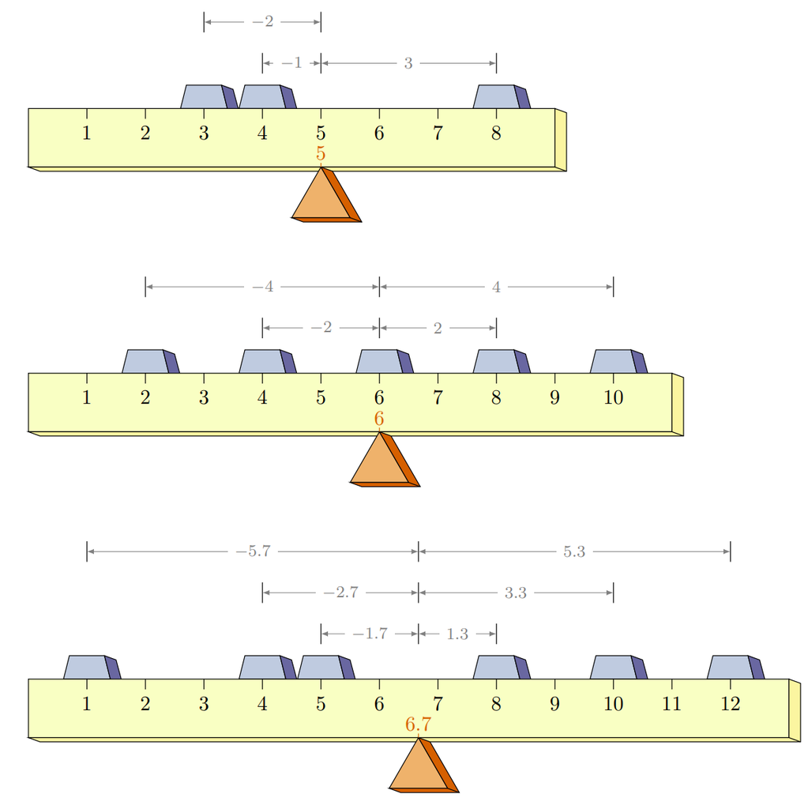

## Median

- The middle observation in an ordered set (if \(n\) is an odd number) or the mean of the two middle observations in an ordered set (if \(n\) is an even number.)
- Insensitive to outliers

[figure not shown]

### 2018 GSS ideal # of children: what’s the **median**?

```r
gss %>% select(chldidel) %>%   # keep the variable you need
  filter(chldidel < 8 ) %>%    # get rid of invalid responses
  group_by(chldidel) %>%       # each answer is own "group"
  add_count(chldidel) %>%      # add count of each response
  slice(1) %>%                 # keep one "rep" from each group
  ungroup() %>%                # forget grouping for mutate
  mutate(prop = n/sum(n) ,     # create proportion column
         cprop = cumsum(prop)) # create cumulative column
```

```
## # A tibble: 8 x 4
##   chldidel     n    prop  cprop
##      <dbl> <int>   <dbl>  <dbl>
## 1        0    18 0.0133  0.0133
## 2        1    34 0.0251  0.0383
## 3        2   691 0.509   0.548
## 4        3   414 0.305   0.853
## 5        4   152 0.112   0.965
## 6        5    27 0.0199  0.985
## 7        6    13 0.00958 0.994
## 8        7     8 0.00590 1
```

### 2018 GSS ideal # of children: what’s the **mode**?

- The most common value in the dataset
- Only makes sense if the variable is discrete rather than continuous

```
## # A tibble: 8 x 4
##   chldidel     n    prop  cprop
##      <dbl> <int>   <dbl>  <dbl>
## 1        0    18 0.0133  0.0133
## 2        1    34 0.0251  0.0383
## 3        2   691 0.509   0.548
## 4        3   414 0.305   0.853
## 5        4   152 0.112   0.965
## 6        5    27 0.0199  0.985
## 7        6    13 0.00958 0.994
## 8        7     8 0.00590 1
```

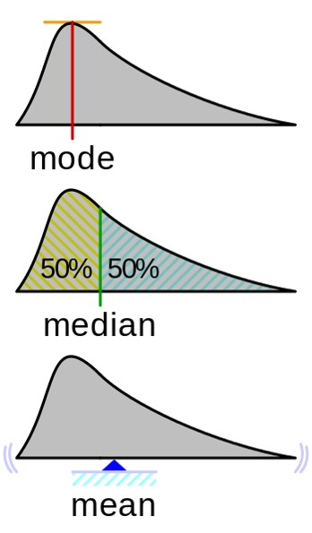

## Quartiles

- Lower quartile = 25th percentile
- Median = 50th percentile
- Upper quartile = 75th percentile

```r
gss %>%
  select(chldidel) %>%
  filter(chldidel<8) %>%
  summary()
```

```
##     chldidel
##  Min.   :0.000
##  1st Qu.:2.000
##  Median :2.000
##  Mean   :2.605
##  3rd Qu.:3.000
##  Max.   :7.000
```

## Interquartile range

- Measure of *dispersion* or spread of the data
- Upper quartile \(-\) lower quartile

```
##     chldidel
##  Min.   :0.000
##  1st Qu.:2.000
##  Median :2.000
##  Mean   :2.605
##  3rd Qu.:3.000
##  Max.   :7.000
```

## Standard deviation

- Another measure of dispersion
- The average deviation from the mean

\[ SD = \sqrt{\frac{1}{n-1}\sum^n_{i=1}(y_i-\bar{y})^2} \]

## Variance

- The square of the standard deviation
- The sum of squared deviations from the mean divided by \(n-1\)
- We usually divide by \(n-1\) (rather than \(n\)) because it reduces bias in finite samples

\[ V = \frac{1}{n-1}\sum^n_{i=1}(y_i-\bar{y})^2 \]

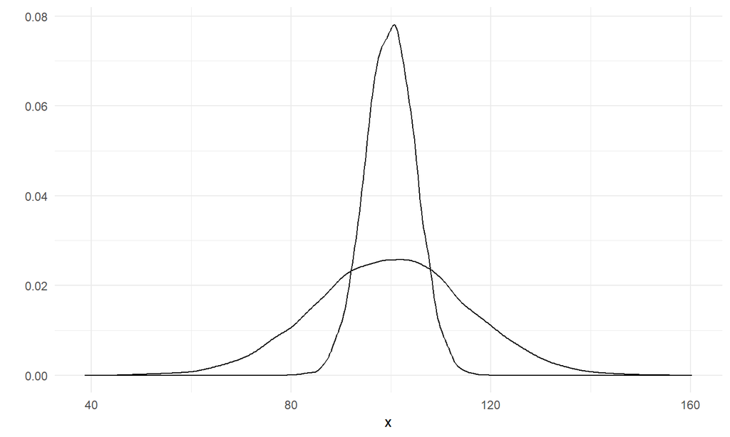

Groups with same means, different SDs

## 3. Observational data

## Why do we use observational data?

- We can’t usually randomize treatment (e.g., divorce, education)
- Observational means the treatment is assigned by some other process than researcher selection (e.g., subject choice)

\(~\)

- The **external validity** is often better (generalization)
- The **internal validity** is worse
  - Pre-treatment differences
  - Confounding bias
  - Selection bias
  - Statistical control is needed
  - Unobserved counfounding is a major threat

## Example datasets in Sociology

- General Social Survey (GSS)
- Add Health
- Panel Study of Income Dynamics (PSID)
- National Study of Youth and Religion (NSYR)
- World Values Survey
- International Social Survey Programme (ISSP)
- European Social Survey (ESS)

## 4. Using observational data

## This is what we’d like

\[ \text{SATE} = \frac{1}{n}\sum_{i=1}^{n}(y^1_i - y^0_i) \]

Recall that because we can’t observe both potential outcomes for each case, we can’t calculate this directly.

## In an experiment it’s easier

### The difference-in-means estimator

\[ \frac{1}{n_T}\sum^{n_T}_{i=1}T_iY_i - \frac{1}{n_C}\sum^{n_C}_{i=1}(1-T_i)Y_i \]

## Confounding

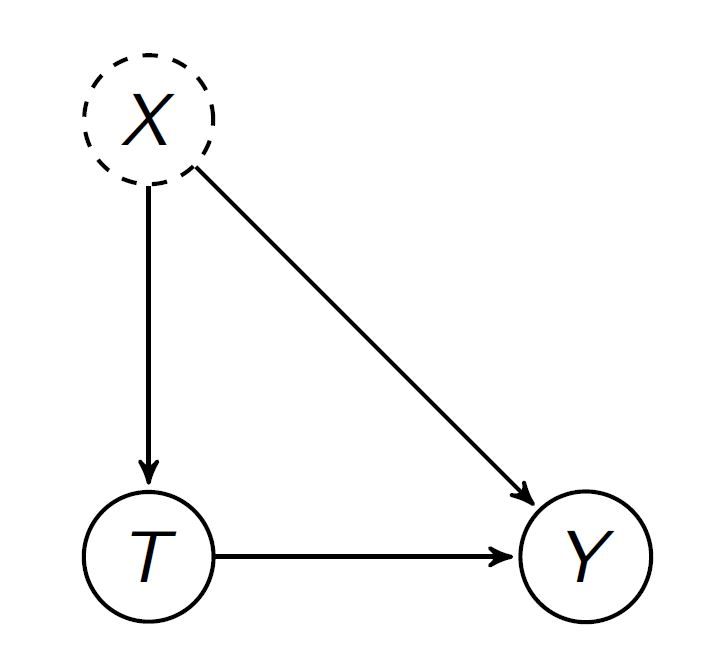

- Key assumption of experiments is **unconfoundedness**
- For observational data, how do we find a good comparison group?

## Example

### Admissions to 6 different Berkeley graduate programs in 1973

```r
data("admissions", package = "dslabs")
admissions %>%
  rename( admit_pct = admitted ) %>%                   # misleading var name
  group_by( gender ) %>%
  summarize( rate = weighted.mean( admit_pct , applicants ) )
```

```
## # A tibble: 2 x 2
##   gender  rate
##   <chr>  <dbl>
## 1 men     44.5
## 2 women   30.3
```

**Why do we have to be more careful interpreting this difference than in an audit study?**

## Statistical control by subclassification

### Question: is there gender discrimination in admissions?

### What if we look separately by program?

```
##    major gender admitted applicants
## 1      A    men       62        825
## 2      B    men       63        560
## 3      C    men       37        325
## 4      D    men       33        417
## 5      E    men       28        191
## 6      F    men        6        373
## 7      A  women       82        108
## 8      B  women       68         25
## 9      C  women       34        593
## 10     D  women       35        375
## 11     E  women       24        393
## 12     F  women        7        341
```

- Women applied to more selective programs
- When we compare *within programs*, we are closer to the true effect of gender
- Why might this still not be enough control for confounding?

```r
admissions %>%
  rename( admit_pct = admitted ) %>%
  mutate( diff = admit_pct - lag(admit_pct , n = 6 ) ,
          totapps = applicants + lag(applicants, n = 6) ) %>%
  filter( gender == "women" ) %>%
  summarize( gender_diff = weighted.mean( diff , totapps ) )
```

```
##   gender_diff
## 1    4.152232
```

Assuming our statistical control was successful, this 4 percentage-point advantage for female students would be our estimate of the **Sample Average Treatment Effect** (SATE).

## Book covers three main strategies for causal inference

1. Cross-sectional comparison (incl. subclassification)
2. Before-and-after design
3. Difference-in-differences

## Card and Krueger example

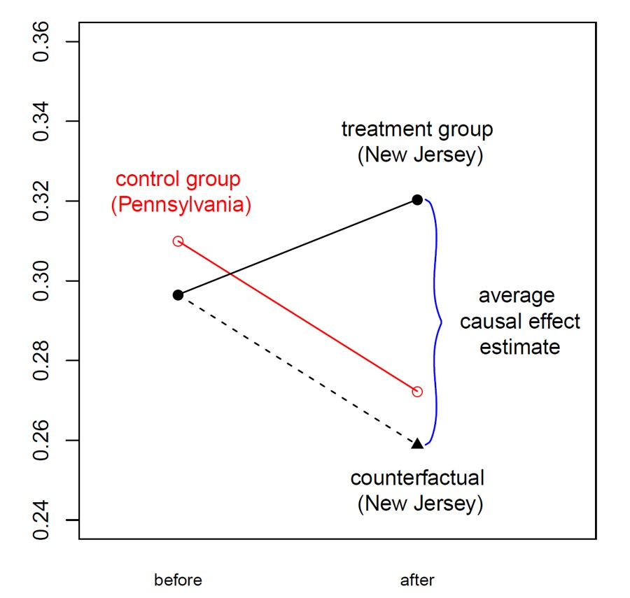

## Example: Basque terrorism

- Basque region hit with terrorism in early 1970s
  - From 1973 to late 1990s, ETA killed almost 800 people
  - Goal: independent Basque state
  - Financing: kidnappings, extortion, robberies
  - Activity localized to Basque area
- Question: what is the economic impact of terrorism?
  - Basque was 3rd richest region in Spain at onset
  - Dropped to 6th position by late 1990s
- Counterfactually speaking: How would Basque economy have fared in the absence of terrorism?

[figure not shown]

## Applying the three identification strategies

Basque region experiences terrorism (*treatment*)

Other Spanish regions did not (*control*)

\(~\)

What does each strategy assume?

```r
bd <- read_csv(here("data", "basque.csv"))
glimpse(bd)
```

```
## Observations: 731
## Variables: 3
## $ region <chr> "Andalucia", "Andalucia", "Andalucia", "Andalucia", "An...
## $ year   <dbl> 1955, 1956, 1957, 1958, 1959, 1960, 1961, 1962, 1963, 1...
## $ gdpcap <dbl> 1.688732, 1.758498, 1.827621, 1.852756, 1.878035, 2.010...
```

```r
skimr::skim_with(numeric = list(hist = NULL)) # only for slides
skimr::skim(bd)
```

```
## Skim summary statistics
##  n obs: 731
##  n variables: 3
##
## -- Variable type:character ---------------------------
##  variable missing complete   n min max empty n_unique
##    region       0      731 731   5  22     0       17
##
## -- Variable type:numeric -----------------------------
##  variable missing complete   n   mean    sd      p0     p25     p50
##    gdpcap       0      731 731    5.4  2.26    1.24    3.69    5.28
##      year       0      731 731 1976   12.42 1955    1965    1976
##      p75    p100
##     6.87   12.35
##  1987    1997
```

```r
bd <- bd %>%
  mutate( basque = if_else( region == "Basque Country" , 1L , 0L ) ,
          after = if_else( year >= 1973 , 1L , 0L ))

means <- bd %>%
  group_by( basque , after ) %>%
  summarize( gdpcap = mean( gdpcap ))

means
```

```
## # A tibble: 4 x 3
## # Groups:   basque [2]
##   basque after gdpcap
##    <int> <int>  <dbl>
## 1      0     0   3.48
## 2      0     1   6.64
## 3      1     0   5.10
## 4      1     1   7.77
```

```r
means
```

```
## # A tibble: 4 x 3
## # Groups:   basque [2]
##   basque after gdpcap
##    <int> <int>  <dbl>
## 1      0     0   3.48
## 2      0     1   6.64
## 3      1     0   5.10
## 4      1     1   7.77
```

```r
# Cross-section
means[4,3] - means[2,3]
```

```
##     gdpcap
## 1 1.132917
```

```r
# Before and after
means[4,3] - means[3,3]
```

```
##     gdpcap
## 1 2.678146
```

```r
# Difference in difference
(means[4,3] - means[3,3]) -
  (means[2,3] - means[1,3])
```

```
##     gdpcap
## 1 -0.48316
```

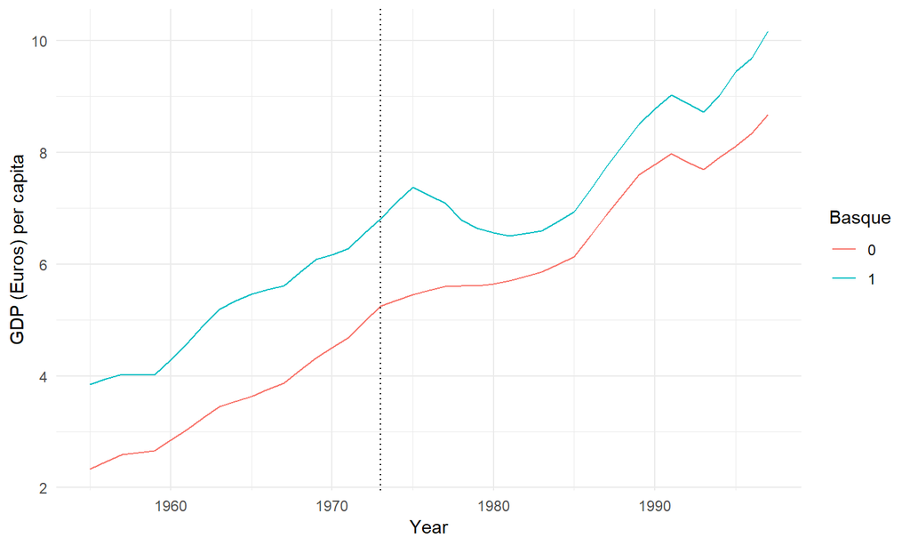

## Different strategies, different assumptions

- All the strategies are attempts at finding a good **counterfactual** comparison
- Ideally, we want to compare “treated” cases that are alike in every way *except* for the treatment
- Difference-in-difference (and related) approaches require repeated measurements *over time*, which we don’t always have
- In practice, we’re often doing statistical control by subclassification (or related “control” strategies)

## What would be good comparions?

- Effect of a college degree on earnings
- Effect of universal health care on average life expectancy in a country
- Effect of weekly church attendance on conservatism
- Effect of having a friend who exercises on a person’s own exercise
- Effect of incarceration on depression

[figure not shown]